# Student Name:Dhaniswar B.K. And StudentId:NP03A190318

# USE of Multivariate Regression on DIABETES Dataset

```python
import pandas as pd
import numpy as np
from matplotlib import pyplot as plt
%matplotlib inline
```

importing pandas library ,numpy and pyplot library

```python
Data = pd.read_csv("diabetes.csv")
Data
```

|  | Pregnancies | Glucose | BloodPressure | SkinThickness | Insulin | BMI | DiabetesPedigreeFunction | Age | Outcome |
| --- | --- | --- | --- | --- | --- | --- | --- | --- | --- |
| 0 | 6 | 148 | 72 | 35 | 0 | 33.6 | 0.627 | 50 | 1 |
| 1 | 1 | 85 | 66 | 29 | 0 | 26.6 | 0.351 | 31 | 0 |
| 2 | 8 | 183 | 64 | 0 | 0 | 23.3 | 0.672 | 32 | 1 |
| 3 | 1 | 89 | 66 | 23 | 94 | 28.1 | 0.167 | 21 | 0 |
| 4 | 0 | 137 | 40 | 35 | 168 | 43.1 | 2.288 | 33 | 1 |
| ... | ... | ... | ... | ... | ... | ... | ... | ... | ... |
| 763 | 10 | 101 | 76 | 48 | 180 | 32.9 | 0.171 | 63 | 0 |
| 764 | 2 | 122 | 70 | 27 | 0 | 36.8 | 0.340 | 27 | 0 |
| 765 | 5 | 121 | 72 | 23 | 112 | 26.2 | 0.245 | 30 | 0 |
| 766 | 1 | 126 | 60 | 0 | 0 | 30.1 | 0.349 | 47 | 1 |
| 767 | 1 | 93 | 70 | 31 | 0 | 30.4 | 0.315 | 23 | 0 |

768 rows × 9 columns

# reading csv file using pandas and converting header to numeric form to apply multivariate linear Regression

```python
Data = pd.read_csv("diabetes.csv",header=None)
Data
```

|  | 0 | 1 | 2 | 3 | 4 | 5 | 6 | 7 | 8 |
| --- | --- | --- | --- | --- | --- | --- | --- | --- | --- |
| 0 | Pregnancies | Glucose | BloodPressure | SkinThickness | Insulin | BMI | DiabetesPedigreeFunction | Age | Outcome |
| 1 | 6 | 148 | 72 | 35 | 0 | 33.6 | 0.627 | 50 | 1 |
| 2 | 1 | 85 | 66 | 29 | 0 | 26.6 | 0.351 | 31 | 0 |
| 3 | 8 | 183 | 64 | 0 | 0 | 23.3 | 0.672 | 32 | 1 |
| 4 | 1 | 89 | 66 | 23 | 94 | 28.1 | 0.167 | 21 | 0 |
| ... | ... | ... | ... | ... | ... | ... | ... | ... | ... |
| 764 | 10 | 101 | 76 | 48 | 180 | 32.9 | 0.171 | 63 | 0 |
| 765 | 2 | 122 | 70 | 27 | 0 | 36.8 | 0.34 | 27 | 0 |
| 766 | 5 | 121 | 72 | 23 | 112 | 26.2 | 0.245 | 30 | 0 |
| 767 | 1 | 126 | 60 | 0 | 0 | 30.1 | 0.349 | 47 | 1 |
| 768 | 1 | 93 | 70 | 31 | 0 | 30.4 | 0.315 | 23 | 0 |

769 rows × 9 columns

#loading data from pandas and making header none and gisplaying data

```python
Data[0] = Data[0].replace("Pregnancies",1)
Data[1] = Data[1].replace("Glucose",1)
Data[2] = Data[2].replace("BloodPressure",1)
Data[3] = Data[3].replace("SkinThickness",1)
Data[4] = Data[4].replace("Insulin",1)
Data[5] = Data[5].replace("BMI",1)
Data[6] = Data[6].replace("DiabetesPedigreeFunction",1)
Data[7] = Data[7].replace("Age",1)
Data[8] = Data[8].replace("Outcome",1)
Data
```

|  | 0 | 1 | 2 | 3 | 4 | 5 | 6 | 7 | 8 |
| --- | --- | --- | --- | --- | --- | --- | --- | --- | --- |
| 0 | 1 | 1 | 1 | 1 | 1 | 1 | 1 | 1 | 1 |
| 1 | 6 | 148 | 72 | 35 | 0 | 33.6 | 0.627 | 50 | 1 |
| 2 | 1 | 85 | 66 | 29 | 0 | 26.6 | 0.351 | 31 | 0 |
| 3 | 8 | 183 | 64 | 0 | 0 | 23.3 | 0.672 | 32 | 1 |
| 4 | 1 | 89 | 66 | 23 | 94 | 28.1 | 0.167 | 21 | 0 |
| ... | ... | ... | ... | ... | ... | ... | ... | ... | ... |
| 764 | 10 | 101 | 76 | 48 | 180 | 32.9 | 0.171 | 63 | 0 |
| 765 | 2 | 122 | 70 | 27 | 0 | 36.8 | 0.34 | 27 | 0 |
| 766 | 5 | 121 | 72 | 23 | 112 | 26.2 | 0.245 | 30 | 0 |
| 767 | 1 | 126 | 60 | 0 | 0 | 30.1 | 0.349 | 47 | 1 |
| 768 | 1 | 93 | 70 | 31 | 0 | 30.4 | 0.315 | 23 | 0 |

769 rows × 9 columns

```python
X = Data.drop(columns=8).astype('float64')
X
```

|  | 0 | 1 | 2 | 3 | 4 | 5 | 6 | 7 |
| --- | --- | --- | --- | --- | --- | --- | --- | --- |
| 0 | 1.0 | 1.0 | 1.0 | 1.0 | 1.0 | 1.0 | 1.000 | 1.0 |
| 1 | 6.0 | 148.0 | 72.0 | 35.0 | 0.0 | 33.6 | 0.627 | 50.0 |
| 2 | 1.0 | 85.0 | 66.0 | 29.0 | 0.0 | 26.6 | 0.351 | 31.0 |
| 3 | 8.0 | 183.0 | 64.0 | 0.0 | 0.0 | 23.3 | 0.672 | 32.0 |
| 4 | 1.0 | 89.0 | 66.0 | 23.0 | 94.0 | 28.1 | 0.167 | 21.0 |
| ... | ... | ... | ... | ... | ... | ... | ... | ... |
| 764 | 10.0 | 101.0 | 76.0 | 48.0 | 180.0 | 32.9 | 0.171 | 63.0 |
| 765 | 2.0 | 122.0 | 70.0 | 27.0 | 0.0 | 36.8 | 0.340 | 27.0 |
| 766 | 5.0 | 121.0 | 72.0 | 23.0 | 112.0 | 26.2 | 0.245 | 30.0 |
| 767 | 1.0 | 126.0 | 60.0 | 0.0 | 0.0 | 30.1 | 0.349 | 47.0 |
| 768 | 1.0 | 93.0 | 70.0 | 31.0 | 0.0 | 30.4 | 0.315 | 23.0 |

769 rows × 8 columns

dividing input data using drop function and repacing string value with float using astype function

```python
y = Data.iloc[:,8:].astype('float64')
y
```

|  | 8 |
| --- | --- |
| 0 | 1.0 |
| 1 | 1.0 |
| 2 | 0.0 |
| 3 | 1.0 |
| 4 | 0.0 |
| ... | ... |
| 764 | 0.0 |
| 765 | 0.0 |
| 766 | 0.0 |
| 767 | 1.0 |
| 768 | 0.0 |

769 rows × 1 columns

```python
theta = np.array([0]*len(X.columns))
```

initializing theta value initially 0 using numpy dot array

```python
m = len(Data)
m
```

```
769
```

#length of training set

```python
def hypothesis(theta, X):
    return theta*X
```

Creating hypotheis function it is a hypothesis function it gives hypothetic value which is theta*X

```python
def computeCost(X,y, theta):
    y1 = hypothesis(theta,X)
    y1 = np.sum(y1, axis = 1)
    return sum(np.sqrt((y1-y)**2))/(2*m)
```

```python
def gradientDescent(X,y,theta,alpha,i):
    J = [] #cost function in each iterations
    k = 0
    while k < i:
        y1 = hypothesis(theta, X)
        y1 = np.sum(y1,axis=1)
        for C in range(0, len(X.columns)):
            theta[C] = theta[C] - alpha*(sum((y1-y)*X.iloc[:,C])/len(X))
        j = computeCost(X, y, theta)
        J.append(j)
        k += 1
    return J, j, theta
```

optimizing bias tearm and it gives optimize theta by differentiation multivariate is used for output in iteration

```python
J, j, theta = gradientDescent(X, y, theta, 0.5, 1000)
```

Call gradient descent where 0.5 is value of alpha and 1000 is value of iteration our target is difference between predicted and hypothetical value should be nearly equal to zero

```python
y_hat = hypothesis(theta, X)
y_hat = np.sum(y_hat, axis=1)
```

call hypothesis it means predict output and theta = optimize theta and X input where y_hat is predicted data

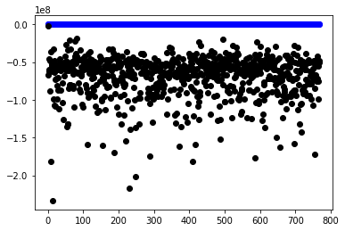

```python
 %matplotlib inline
import matplotlib.pyplot as plt
plt.figure()
plt.scatter(x=list(range(0, 769)),y= y, color="blue")
plt.scatter(x=list(range(0, 769)),y= y_hat, color="black")
plt.show()
```

showing the distane between y and y_hat it meand distance between original data and predicted data where black data is predicted and blue data is origional

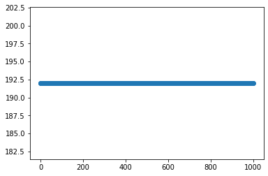

```python
plt.figure()
plt.scatter(x=list(range(0, 1000)), y=J)
plt.show()
```

platting the cost function where J is a cost function

```python
from sklearn.linear_model import LinearRegression
from sklearn.model_selection import train_test_split
X_train, X_test, y_train, y_test = train_test_split(X,y, test_size=0.01, random_state = 95)
```

importing linear regression And importing train_test_split from sklearn to split data into trannig and testing set

```python
model = LinearRegression()
model.fit(X_train, y_train)
predictions = model.predict(X_test)
```

```python
model.fit(X_train, y_train)
```

```
LinearRegression()
```

```python
model.score(X_test,y_test)
```

```
0.7119361973183576
```

```python
from sklearn.metrics import mean_squared_error, mean_absolute_error
```

importing mean_squared_error and mean_absolute_error to claculate MSE, MAE and RMSE

```python
# np.mean((y_test - predictions)**2)
mse = mean_squared_error( y_test, predictions) # calculating MSE
mse
```

```
0.07201595067041063
```

```python
mae = mean_absolute_error(y_test, predictions) # calculating MAE
mae
```

```
0.19570865608559376
```

```python
rmse = np.sqrt(mse)
```

```python
rmse #calculating MAE
```

```
0.2683578779734454
```